# Pets!

Andrew Ramirez

March 30, 2021

I live in East Sacramento and while I’m not a big cat guy (mainly due to being allergic),  
plenty of neighborhood cats stroll into my backyard.

While observing these cats, an idea came to me. How did the impact of COVID-19 affect animal shelters in Sacramento? To answer that, I took to City of Sacramento datasets and started exploring.

I created visualizations to illustrate how animals end up in a shelter, the color of the animals admitted, and type of animal (i.e Cat or Dog) most commonly admitted.

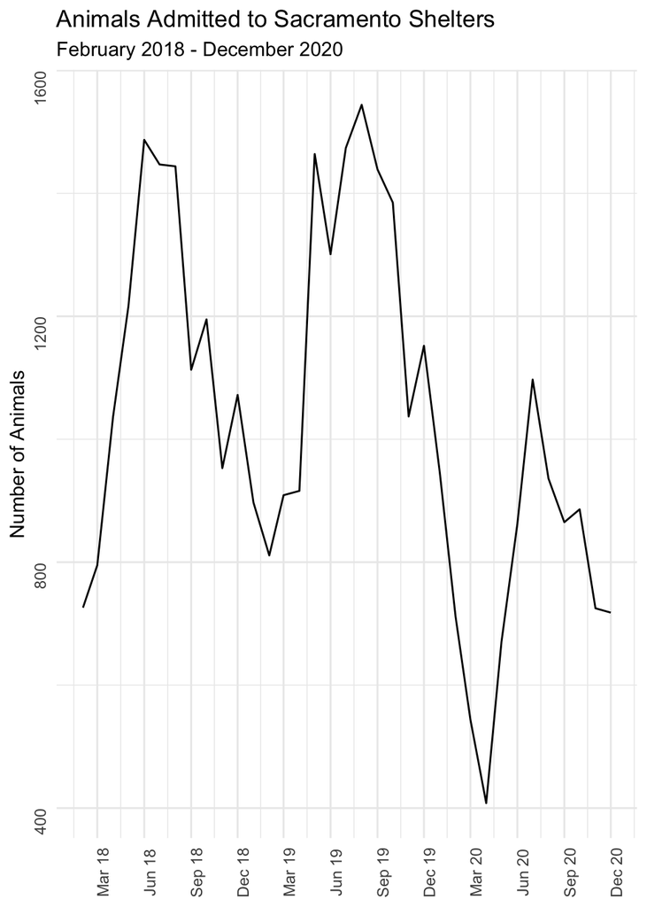

To get context for how many animals were admitted to shelters during 2020 I decided to create a time series. The time series shows the seasonality in the data. Animals are admitted to shelters more in the spring/summer months and less in the winter months. What’s interesting about 2020 is that the number of animals admitted into the shelters fell precipitously around the same time governments enacted lockdowns and quarantines. Logically, I’d assume more would be taken into shelters as economic factors like unemployment skyrocketed. However, a case could be made that less animals were admitted as their were less people outside (due to lockdowns) to notify/ call in the animals.

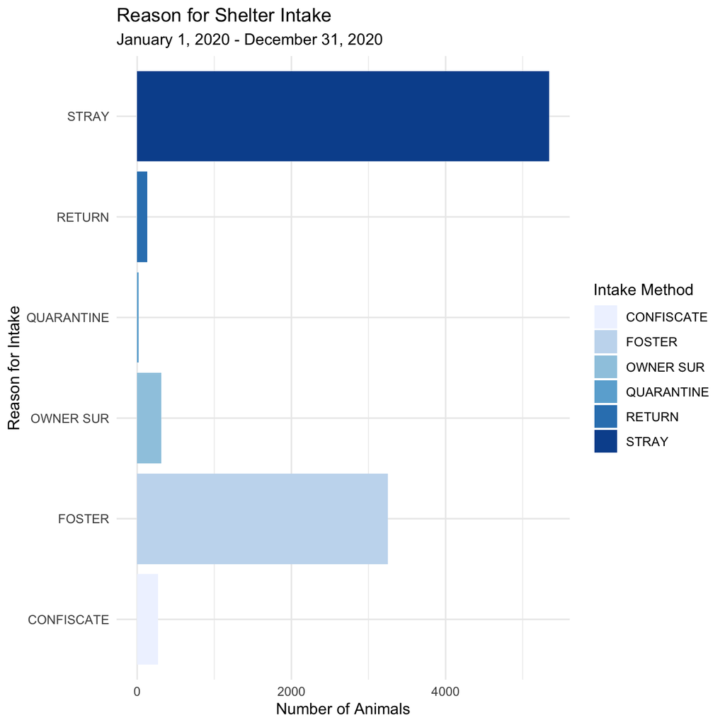

Next, I wanted to understand the reasons that animals were brought into shelters. Pictured above are the top six reasons for why animals got taken to a shelter. The most common reason animals ended up in a shelter was because they were taken in as a stray. The second reason animals were brought to shelters was due to individuals returning a fostered pet.

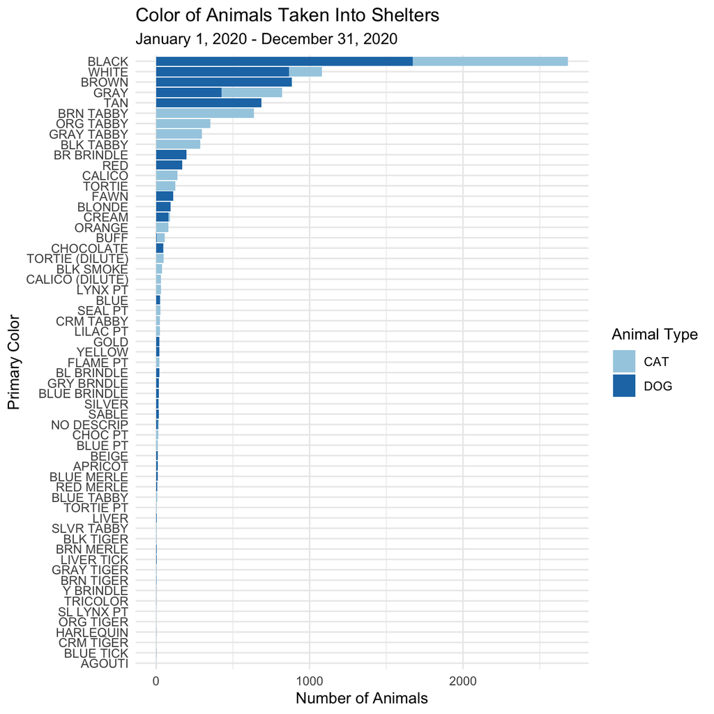

The color of animals brought to shelters were skewed towards generic colors. In aggregate and as standalone, black, white, brown, gray, and tan animals got taken to Sacramento shelters more than any other. The color distribution make sense as the most popular dog breeds are Labradors, German Shepherds, and Poodles. Similarly, the most common hair color for cats is black as it is one of their dominant traits as a species.

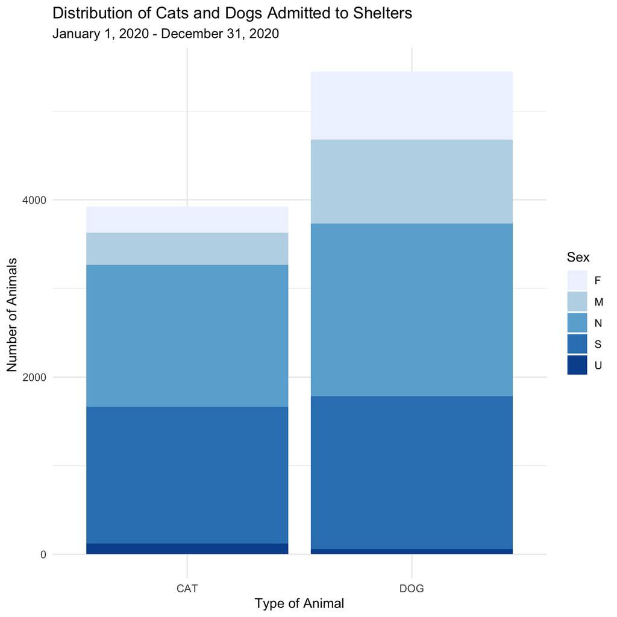